# Analysis of Smart Device Usage for Strategic Marketing Insights at Bellabeat

Emmett Demirhan

2023-12-06

## Executive Summary

This analysis presents strategic insights into smart device usage for Bellabeat, a high-tech producer of health-focused products for women. The study used data from Fitbit fitness trackers to understand user behaviours in physical activity, sleep monitoring, and heart rate trends to enhance Bellabeat’s marketing strategies.

The strategic recommendations for Bellabeat based on this analysis include developing personalised sleep insights, sedentary behaviour alerts, and wellness content targeting less active days. Furthermore, expanding data collection to include demographic information would enable more targeted marketing strategies.

These insights could be implemented through product development, marketing campaigns, and customer engagement initiatives that align with the identified user behaviours. Continuous monitoring of strategy effectiveness and data-driven adjustments are essential for sustained impact.

In conclusion, while the dataset provides valuable insights, it is limited by its size, scope, and the fact that it is somewhat dated. To maximise the efficacy of the derived strategies, Bellabeat is advised to invest in more comprehensive and current data collection, including demographic details, to ensure that the insights and recommendations reflect its target market’s behaviours and needs.

## Business Task Overview

#### Objective:

The primary objective of this analysis is to provide Bellabeat, a high-tech manufacturer of health-focused products for women, with actionable insights derived from the analysis of smart device usage data. This analysis is aimed at informing and enhancing the company’s marketing strategies.

#### Background:

Bellabeat, established in 2013, has been at the forefront of developing innovative, health-focused smart products designed specifically for women. With a range of products including the Bellabeat app, Leaf, Time, and Spring, the company has made significant strides in integrating technology with wellness. However, to keep pace with the dynamic smart device market and to capitalize on potential growth opportunities, a deeper understanding of consumer behavior and device usage is essential.

#### Problem Statement:

Despite Bellabeat’s success in creating aesthetically pleasing and functional wellness products, there is a need to understand the broader trends in smart device usage. This understanding is crucial to tailor Bellabeat’s marketing strategies effectively, ensuring they resonate with the target audience’s habits and preferences.

#### Significance:

By analyzing existing smart device usage data, specifically from non-Bellabeat products like Fitbit, I aim to uncover trends and patterns that can inform Bellabeat’s marketing strategies. This analysis will help Bellabeat to align its products with consumer needs, preferences, and lifestyle choices, thereby enhancing customer engagement and market share.

#### Approach:

My approach involves a detailed analysis of the FitBit Fitness Tracker Data to explore user habits in areas such as physical activity, heart rate monitoring, and sleep patterns. This data, though external, provides a valuable proxy to understand potential behaviors and preferences of Bellabeat’s current and prospective customer base.

## Ask

#### Analysis Goals:

In this phase of the analysis, the goal is to identify and clarify the key questions that will drive the data exploration and analysis. These questions are designed to uncover insights into smart device usage trends that are applicable and beneficial to Bellabeat’s marketing strategy and product development.

#### Key Questions:

1. **Sleep and Activity Correlation**: How do sleep patterns correlate with physical activity levels among smart device users?
2. **User Engagement Timing**: What are the peak activity hours where user engagement with Bellabeat products could be maximized?
3. **Behavioral Insights Application**: How can insights into sedentary and active behaviours inform product enhancements and marketing strategies?
4. **Data-Driven Product Development**: What features can be added or improved in Bellabeat products to cater to the identified needs and habits of the target audience?

#### Approach:

- Conduct an in-depth correlation analysis to explore the relationships between different health metrics.
- Utilize time-series analysis to identify peak activity periods for targeted engagement strategies.
- Analyse behavioral trends to inform both product development and marketing messaging.

#### Stakeholder Engagement:

Throughout this phase, engagement with key stakeholders, including Bellabeat’s marketing team and product development unit, would be vital. Their input would ensure that the analysis remains aligned with the company’s business goals and market positioning strategies.

## Prepare

#### Data Description and Storage

##### Storage:

The dataset consists of 18 CSV files, stored locally on my machine and also on [GitHub repository](https://github.com/EmmettDemirhan/Google_Data_Analytics_Capstone_Project/tree/main/Fitabase_Data) for ease of access and analysis. The files are organized in a dedicated directory, ensuring efficient management and retrieval during the analysis process.

#### Data Credibility and Integrity

##### Addressing Limitations:

- Explore additional datasets that could complement and enhance this dataset.
- Conduct a thorough exploratory data analysis to identify and understand any gaps or inconsistencies in the data.

#### Data Privacy and Ethics

The data used in this analysis is sourced from the publicly available FitBit Fitness Tracker dataset on Kaggle. It contains anonymised information, ensuring no personal or identifiable data of participants is revealed.

## Process

#### Data and Libraries Loading

Here, I load each CSV file from the FitBit Fitness Tracker Data into R and conduct a preliminary examination.

```r
# Load Libraries
library('tidyverse')
library('janitor')
library('skimr')
library('here')
library('dplyr')
library(tidyr)
library(lubridate)
library(ggplot2)
library(corrplot)
library(knitr)
library(viridis)
library(GGally)

# File names
file_names <- c("dailyActivity_merged.csv", "dailyCalories_merged.csv",
                "dailyIntensities_merged.csv", "dailySteps_merged.csv",
                "heartrate_seconds_merged.csv", "hourlyCalories_merged.csv",
                "hourlyIntensities_merged.csv", "hourlySteps_merged.csv",
                "minuteCaloriesNarrow_merged.csv", "minuteCaloriesWide_merged.csv",
                "minuteMETsNarrow_merged.csv", "minuteSleep_merged.csv",
                "minuteStepsNarrow_merged.csv", "minuteStepsWide_merged.csv",
                "sleepDay_merged.csv", "weightLogInfo_merged.csv",
                "minuteIntensitiesNarrow_merged.csv", "minuteIntensitiesWide_merged.csv")

# Function to clean dataset names
clean_dataset_name <- function(name) {
    name %>%
    str_replace_all("([a-z])([A-Z])", "\\1_\\2") %>%  # Insert underscore before a capital letter
    tolower() %>%  # Convert to lower case
    str_replace_all("__", "_") %>%  # Replace double underscores with a single one
    str_trim()  # Trim whitespace
}

# Loop to read each file, assign to a cleaned variable name, and store names in list
datasets <- c()  # Initialize an empty vector to store cleaned dataset names
for (file in file_names) {
    var_name <- sub("\\_merged.csv$", "", file)  # Create variable name
    cleaned_var_name <- clean_dataset_name(var_name)  # Clean the variable name
    file_path <- paste0("Fitabase_Data/", file)  # File path
    dataset <- read_csv(file_path) %>% clean_names()  # Read and clean column names
    assign(cleaned_var_name, dataset)  # Assign cleaned dataset to cleaned variable name
    datasets <- c(datasets, cleaned_var_name)  # Store cleaned dataset name
}
 datasets
```

```
##  [1] "daily_activity"            "daily_calories"
##  [3] "daily_intensities"         "daily_steps"
##  [5] "heartrate_seconds"         "hourly_calories"
##  [7] "hourly_intensities"        "hourly_steps"
##  [9] "minute_calories_narrow"    "minute_calories_wide"
## [11] "minute_mets_narrow"        "minute_sleep"
## [13] "minute_steps_narrow"       "minute_steps_wide"
## [15] "sleep_day"                 "weight_log_info"
## [17] "minute_intensities_narrow" "minute_intensities_wide"
```

#### Inspecting each dataset

```r
# Loop through each dataset, print its name, dimensions, and column names
for (dataset in datasets) {
  cat("\nDataset name:", dataset, "\n")
  data <- get(dataset)

  # Display number of rows and columns
  cat("Dimensions (Rows x Columns):", dim(data)[1], "x", dim(data)[2], "\n")

  # Display the names of the columns
  cat("Column Names:", toString(names(data)), "\n")
}
```

```
##
## Dataset name: daily_activity
## Dimensions (Rows x Columns): 940 x 15
## Column Names: id, activity_date, total_steps, total_distance, tracker_distance, logged_activities_distance, very_active_distance, moderately_active_distance, light_active_distance, sedentary_active_distance, very_active_minutes, fairly_active_minutes, lightly_active_minutes, sedentary_minutes, ca…
##
## Dataset name: daily_calories
## Dimensions (Rows x Columns): 940 x 3
## Column Names: id, activity_day, calories
##
## Dataset name: daily_intensities
## Dimensions (Rows x Columns): 940 x 10
## Column Names: id, activity_day, sedentary_minutes, lightly_active_minutes, fairly_active_minutes, very_active_minutes, sedentary_active_distance, light_active_distance, moderately_active_distance, very_active_distance
##
## Dataset name: daily_steps
## Dimensions (Rows x Columns): 940 x 3
## Column Names: id, activity_day, step_total
##
## Dataset name: heartrate_seconds
## Dimensions (Rows x Columns): 2483658 x 3
## Column Names: id, time, value
##
## Dataset name: hourly_calories
## Dimensions (Rows x Columns): 22099 x 3
## Column Names: id, activity_hour, calories
##
## Dataset name: hourly_intensities
## Dimensions (Rows x Columns): 22099 x 4
## Column Names: id, activity_hour, total_intensity, average_intensity
##
## Dataset name: hourly_steps
## Dimensions (Rows x Columns): 22099 x 3
## Column Names: id, activity_hour, step_total
##
## Dataset name: minute_calories_narrow
## Dimensions (Rows x Columns): 1325580 x 3
## Column Names: id, activity_minute, calories
##
## Dataset name: minute_calories_wide
## Dimensions (Rows x Columns): 21645 x 62
## Column Names: id, activity_hour, calories00, calories01, calories02, calories03, calories04, calories05, calories06, calories07, calories08, calories09, calories10, calories11, calories12, calories13, calories14, calories15, calories16, calories17, calories18, calories19, calories20, calories21, …
```

[output cut: 17 more lines]

```
## Dataset name: sleep_day
## Dimensions (Rows x Columns): 413 x 5
## Column Names: id, sleep_day, total_sleep_records, total_minutes_asleep, total_time_in_bed
##
## Dataset name: weight_log_info
## Dimensions (Rows x Columns): 67 x 8
## Column Names: id, date, weight_kg, weight_pounds, fat, bmi, is_manual_report, log_id
##
## Dataset name: minute_intensities_narrow
## Dimensions (Rows x Columns): 1325580 x 3
## Column Names: id, activity_minute, intensity
##
## Dataset name: minute_intensities_wide
## Dimensions (Rows x Columns): 21645 x 62
## Column Names: id, activity_hour, intensity00, intensity01, intensity02, intensity03, intensity04, intensity05, intensity06, intensity07, intensity08, intensity09, intensity10, intensity11, intensity12, intensity13, intensity14, intensity15, intensity16, intensity17, intensity18, intensity19, inte…
```

```r
# # Loop through each dataset, print its name and use glimpse to view its structure
# for (dataset in datasets) {
#   cat("\nDataset name:", dataset, "\n")
#   get(dataset) %>% glimpse()
# }
# it is too long to display so I commended this chuck after inspection
```

Interpreting the output, it’s evident that the Fitbit dataset offers a comprehensive view of user activity, encompassing various aspects like daily activity levels, calorie consumption, sleep patterns, heart rate, and intensity of physical activities. The presence of both granular (minute-level) and aggregated (daily, hourly) data allows for a detailed examination of user behaviors. However, some datasets appear to be redundant, such as daily_activity overlapping with individual daily_calories, daily_steps, and daily_intensities, and similarly, minute_calories_narrow vs. minute_calories_wide. The weight_log_info dataset, although small, provides valuable insights into weight and BMI trends, which can be correlated with activity data for more in-depth analysis.

From these datasets, valuable insights can be garnered to inform Bellabeat’s marketing and product strategies. By analysing daily activity patterns and calorie burn, we can understand the typical user’s fitness routines and tailor marketing messages to fit these habits. The sleep data provides an avenue to explore how Bellabeat’s products can enhance sleep quality and wellness routines. The minute-level data offer a rich source for understanding the intensity and duration of physical activities, potentially revealing when users are most active and how they engage with fitness. This granular analysis could guide the development of personalized features in Bellabeat products. Finally, examining the correlations between different datasets, like activity levels and weight changes, can reveal deeper behavioral insights, helping Bellabeat to position its products as effective tools for holistic health management.

#### Data Cleaning and Manipulation

##### Trasnforming the date columns

```r
# Standardize and convert date columns to a consistent format
convert_and_rename_date <- function(df, old_date_column, new_date_column = "date") {
  df <- df %>% rename(!!new_date_column := !!old_date_column)  # Standardize the column name
  df[[new_date_column]] <- mdy(df[[new_date_column]])  # Convert to date format
  return(df)
}

# Applying the function to convert and rename date formats
daily_activity <- convert_and_rename_date(daily_activity, "activity_date")
daily_calories <- convert_and_rename_date(daily_calories, "activity_day")
daily_intensities <- convert_and_rename_date(daily_intensities, "activity_day")
daily_steps <- convert_and_rename_date(daily_steps, "activity_day")

# Function to convert datetime columns to a consistent date format and standardize the name
convert_and_rename_datetime_to_date <- function(df, old_datetime_column, new_date_column = "date") {
  df <- df %>% rename(!!new_date_column := !!old_datetime_column)  # Standardize the column name
  df[[new_date_column]] <- mdy(sub(" .*", "", df[[new_date_column]]))  # Convert datetime to date format
  return(df)
}

# Applying the function to convert datetime to date formats and rename
sleep_day <- convert_and_rename_datetime_to_date(sleep_day, "sleep_day")
weight_log_info <- convert_and_rename_datetime_to_date(weight_log_info, "date")
```

#### Checking unique IDs

```r
# Initialize a data frame to store results
unique_id_counts <- data.frame(dataset_name = character(), unique_ids = numeric(), stringsAsFactors = FALSE)

# Loop to check unique IDs in all datasets
for (dataset_name in datasets) {
    dataset <- get(dataset_name)
    unique_ids <- n_distinct(dataset$id)
    unique_id_counts <- rbind(unique_id_counts, data.frame(dataset_name = dataset_name, unique_ids = unique_ids))
}

# Display the results
print(unique_id_counts)
```

```
##                 dataset_name unique_ids
## 1             daily_activity         33
## 2             daily_calories         33
## 3          daily_intensities         33
## 4                daily_steps         33
## 5          heartrate_seconds         14
## 6            hourly_calories         33
## 7         hourly_intensities         33
## 8               hourly_steps         33
## 9     minute_calories_narrow         33
## 10      minute_calories_wide         33
## 11        minute_mets_narrow         33
## 12              minute_sleep         24
## 13       minute_steps_narrow         33
## 14         minute_steps_wide         33
## 15                 sleep_day         24
## 16           weight_log_info          8
## 17 minute_intensities_narrow         33
## 18   minute_intensities_wide         33
```

#### Checking for duplicates

```r
# Initialize a data frame to store results
duplicate_counts <- data.frame(dataset_name = character(), number_of_duplicates = integer(), stringsAsFactors = FALSE)

# Loop to check for duplicates in all datasets
for (dataset_name in datasets) {
    dataset <- get(dataset_name)
    duplicate_count <- sum(duplicated(dataset))
    duplicate_counts <- rbind(duplicate_counts, data.frame(dataset_name = dataset_name, number_of_duplicates = duplicate_count))
}

# Display the results
print(duplicate_counts)
```

```
##                 dataset_name number_of_duplicates
## 1             daily_activity                    0
## 2             daily_calories                    0
## 3          daily_intensities                    0
## 4                daily_steps                    0
## 5          heartrate_seconds                    0
## 6            hourly_calories                    0
## 7         hourly_intensities                    0
## 8               hourly_steps                    0
## 9     minute_calories_narrow                    0
## 10      minute_calories_wide                    0
## 11        minute_mets_narrow                    0
## 12              minute_sleep                  543
## 13       minute_steps_narrow                    0
## 14         minute_steps_wide                    0
## 15                 sleep_day                    3
## 16           weight_log_info                    0
## 17 minute_intensities_narrow                    0
## 18   minute_intensities_wide                    0
```

#### Removing duplicate inputs

```r
# Initialize a data frame to store results post-removal
post_removal_duplicate_counts <- data.frame(dataset_name = character(), number_of_duplicates_post_removal = integer(), stringsAsFactors = FALSE)

# Loop to remove duplicates from all datasets and check duplicates after removal
for (dataset_name in datasets) {
    dataset <- unique(get(dataset_name))
    assign(dataset_name, dataset)
    duplicate_count_post_removal <- sum(duplicated(dataset))
    post_removal_duplicate_counts <- rbind(post_removal_duplicate_counts, data.frame(dataset_name = dataset_name, number_of_duplicates_post_removal = duplicate_count_post_removal))
}

# Display the results
print(post_removal_duplicate_counts)
```

```
##                 dataset_name number_of_duplicates_post_removal
## 1             daily_activity                                 0
## 2             daily_calories                                 0
## 3          daily_intensities                                 0
## 4                daily_steps                                 0
## 5          heartrate_seconds                                 0
## 6            hourly_calories                                 0
## 7         hourly_intensities                                 0
## 8               hourly_steps                                 0
## 9     minute_calories_narrow                                 0
## 10      minute_calories_wide                                 0
## 11        minute_mets_narrow                                 0
## 12              minute_sleep                                 0
## 13       minute_steps_narrow                                 0
## 14         minute_steps_wide                                 0
## 15                 sleep_day                                 0
## 16           weight_log_info                                 0
## 17 minute_intensities_narrow                                 0
## 18   minute_intensities_wide                                 0
```

#### Checking unique days

```r
# Initialize a data frame to store results
unique_day_counts <- data.frame(dataset_name = character(), number_of_unique_days = integer(), stringsAsFactors = FALSE)

# Loop to check unique days in all datasets
for (dataset_name in datasets) {
    dataset <- get(dataset_name)
    if("date" %in% names(dataset)) {
        unique_days <- length(unique(dataset$date))
        unique_day_counts <- rbind(unique_day_counts, data.frame(dataset_name = dataset_name, number_of_unique_days = unique_days))
    } else {
        unique_day_counts <- rbind(unique_day_counts, data.frame(dataset_name = dataset_name, number_of_unique_days = NA_integer_))
    }
}
# Display the results
print(unique_day_counts)
```

```
##                 dataset_name number_of_unique_days
## 1             daily_activity                    31
## 2             daily_calories                    31
## 3          daily_intensities                    31
## 4                daily_steps                    31
## 5          heartrate_seconds                    NA
## 6            hourly_calories                    NA
## 7         hourly_intensities                    NA
## 8               hourly_steps                    NA
## 9     minute_calories_narrow                    NA
## 10      minute_calories_wide                    NA
## 11        minute_mets_narrow                    NA
## 12              minute_sleep                 49773
## 13       minute_steps_narrow                    NA
## 14         minute_steps_wide                    NA
## 15                 sleep_day                    31
## 16           weight_log_info                    31
## 17 minute_intensities_narrow                    NA
## 18   minute_intensities_wide                    NA
```

I will examine minute_sleep further as number_of_unique_days is 49773 for minute_sleep. It might be an issue with the data type. The NAs are normal as the columns names or types do not match. I will leave them as it is because I will not use these datasets.

##### Compare minute_sleep with sleep_day data for validation

```r
# Assuming 'value' column in minute_sleep indicates minutes asleep

daily_sleep_aggregated <- minute_sleep %>%
  mutate(date = mdy_hms(date) %>% as.Date()) %>%
  group_by(id, date) %>%
  summarize(total_minutes_asleep = sum(value, na.rm = TRUE), .groups = "drop")

# Joining with sleep_day dataset
comparison_df <- sleep_day %>%
  full_join(daily_sleep_aggregated, by = c("id", "date")) %>%
  mutate(difference = total_minutes_asleep.x - total_minutes_asleep.y)

# Checking differences
head(comparison_df) %>%
  select(id, date, total_minutes_asleep.x, total_minutes_asleep.y, difference) %>%
  arrange(desc(abs(difference)))
```

```
## # A tibble: 6 × 5
##           id date       total_minutes_asleep.x total_minutes_asleep.y difference
##        <dbl> <date>                      <dbl>                  <dbl>      <dbl>
## 1 1503960366 2016-04-16                    340                    436        -96
## 2 1503960366 2016-04-15                    412                    480        -68
## 3 1503960366 2016-04-13                    384                    442        -58
## 4 1503960366 2016-04-12                    327                    371        -44
## 5 1503960366 2016-04-19                    304                    336        -32
## 6 1503960366 2016-04-17                    700                    690         10
```

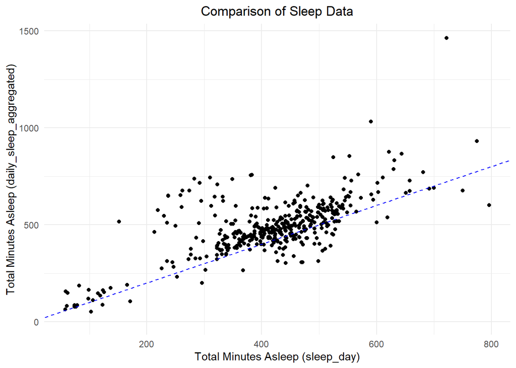

```r
# Create the Plot
ggplot(comparison_df, aes(x = total_minutes_asleep.x, y = total_minutes_asleep.y)) +
  geom_point() +
  labs(x = "Total Minutes Asleep (sleep_day)",
       y = "Total Minutes Asleep (daily_sleep_aggregated)",
       title = "Comparison of Sleep Data") +
  theme_minimal() +
  geom_abline(intercept = 0, slope = 1, linetype = "dashed", color = "blue") +
  theme(plot.title = element_text(hjust = 0.5))  # Centering the title
```

```r
# so checking duplicates
print(paste("Number of duplicates in daily_sleep_aggregated:", sum(duplicated(daily_sleep_aggregated))))
```

```
## [1] "Number of duplicates in daily_sleep_aggregated: 0"
```

```r
# No duplicates, checking how many days I got
# Counting unique days per id
unique_days_sleep <- length(unique(daily_sleep_aggregated$date))
print(paste("Number of unique days:", unique_days_sleep))
```

```
## [1] "Number of unique days: 32"
```

##### Aggregate METs data to daily totals

```r
# Convert 'activity_minute' from character to datetime format
minute_mets_narrow$activity_minute <- as.POSIXct(minute_mets_narrow$activity_minute, format="%m/%d/%Y %I:%M:%S %p")

# Extract date from 'activity_minute'
minute_mets_narrow$date <- as.Date(minute_mets_narrow$activity_minute)

# Aggregate METs data to daily totals
daily_mets <- aggregate(me_ts ~ id + date, minute_mets_narrow, sum)

# Renameing mets columns as mets
daily_mets <- daily_mets %>% rename(mets = me_ts)

# Interestingly 962 columns which is higher than 940 as in daily_activities
# so checking duplicates
print(paste("Number of duplicates in date:", sum(duplicated(daily_mets))))
```

```
## [1] "Number of duplicates in date: 0"
```

```r
# No duplicates, checking how many days I got
# Counting unique days per id
unique_days <- length(unique(daily_mets$date))
print(paste("Number of unique days:", unique_days))
```

```
## [1] "Number of unique days: 32"
```

I got one extra day for daily_mets data too.

##### Further examining daily_activity as tracker_distance and total_distance seem so similar

[figure not shown]

```r
# Create a scatter plot to see difference between tracker_distance and total_distance
plot(daily_activity$tracker_distance, daily_activity$total_distance,
     xlab = "Tracker Distance", ylab = "Total Distance",
     main = "Scatter Plot of Total Steps vs. Total Distance")
```

In this context, it seems that there might be entries made by customers in addition to the data from the tracker devices. Therefore, I use “Total Distance” instead of “Tracker Distance” to understand how the total distance correlates with the total number of steps taken.

```r
# Removing tracker_distance
daily_activity <- daily_activity %>% select(-tracker_distance)
glimpse(daily_activity)
```

```
## Rows: 940
## Columns: 14
## $ id                         <dbl> 1503960366, 1503960366, 1503960366, 1503960…
## $ date                       <date> 2016-04-12, 2016-04-13, 2016-04-14, 2016-0…
## $ total_steps                <dbl> 13162, 10735, 10460, 9762, 12669, 9705, 130…
## $ total_distance             <dbl> 8.50, 6.97, 6.74, 6.28, 8.16, 6.48, 8.59, 9…
## $ logged_activities_distance <dbl> 0, 0, 0, 0, 0, 0, 0, 0, 0, 0, 0, 0, 0, 0, 0…
## $ very_active_distance       <dbl> 1.88, 1.57, 2.44, 2.14, 2.71, 3.19, 3.25, 3…
## $ moderately_active_distance <dbl> 0.55, 0.69, 0.40, 1.26, 0.41, 0.78, 0.64, 1…
## $ light_active_distance      <dbl> 6.06, 4.71, 3.91, 2.83, 5.04, 2.51, 4.71, 5…
## $ sedentary_active_distance  <dbl> 0, 0, 0, 0, 0, 0, 0, 0, 0, 0, 0, 0, 0, 0, 0…
## $ very_active_minutes        <dbl> 25, 21, 30, 29, 36, 38, 42, 50, 28, 19, 66,…
## $ fairly_active_minutes      <dbl> 13, 19, 11, 34, 10, 20, 16, 31, 12, 8, 27, …
## $ lightly_active_minutes     <dbl> 328, 217, 181, 209, 221, 164, 233, 264, 205…
## $ sedentary_minutes          <dbl> 728, 776, 1218, 726, 773, 539, 1149, 775, 8…
## $ calories                   <dbl> 1985, 1797, 1776, 1745, 1863, 1728, 1921, 2…
```

##### Checking Missing Values

```r
# Loop through each dataset and check for missing values
for (dataset in datasets) {
  data <- get(dataset)

  # Calculate the sum of missing values for each column
  missing_values <- sapply(data, function(x) sum(is.na(x)))

  # Filter out columns with no missing values
  missing_values <- missing_values[missing_values > 0]

  # Check if there are any missing values in the dataset
  if (length(missing_values) > 0) {
    # Create a summary string for missing values
    missing_summary_string <- paste("Dataset name:", dataset, "\n",
                                    "Missing Values Summary:\n",
                                    toString(sprintf("%s: %d", names(missing_values), missing_values)),
                                    sep = "\n")

    # Print the summary string
    cat(missing_summary_string, "\n\n")
  }
}
```

Dataset name: weight_log_info

Missing Values Summary:

fat: 65 The output indicates that in the weight_log_info dataset, the only column with missing values is the “fat” column, which has 65 missing entries. This suggests that for a significant number of entries in this dataset, the body fat percentage (or a similar metric represented by the fat column) was not recorded or is unavailable. When analyzing or drawing insights from this dataset, it’s important to consider the impact of these missing values. No other columns in this dataset have missing values.

## Analyse and Share Phase

### Analysing Daily Activities Dataset

```r
# Exclude 'id', 'date', and 'day_of_week' from the analysis
selected_columns <- setdiff(names(daily_activity), c("id", "date", "day_of_week"))

# Create a summary table for these variables
summary_table <- daily_activity %>%
  select(all_of(selected_columns)) %>%
  summarise(across(everything(),
                   list(Mean = ~round(mean(.), 2),
                        Median = ~round(median(.), 2),
                        Min = ~round(min(.), 2),
                        Max = ~round(max(.), 2),
                        SD = ~round(sd(.), 2)),
                   .names = "{col}_{.fn}")) %>%
  pivot_longer(cols = everything(),
               names_to = c("Variable", ".value"),
               names_pattern = "(.*)_(.*)")

# Display the summary table
knitr::kable(summary_table, caption = "Summary Statistics of Daily Activity Variables")
```

Summary Statistics of Daily Activity Variables

| Variable | Mean | Median | Min | Max | SD |
| --- | --- | --- | --- | --- | --- |
| total_steps | 7637.91 | 7405.50 | 0 | 36019.00 | 5087.15 |
| total_distance | 5.49 | 5.24 | 0 | 28.03 | 3.92 |
| logged_activities_distance | 0.11 | 0.00 | 0 | 4.94 | 0.62 |
| very_active_distance | 1.50 | 0.21 | 0 | 21.92 | 2.66 |
| moderately_active_distance | 0.57 | 0.24 | 0 | 6.48 | 0.88 |
| light_active_distance | 3.34 | 3.36 | 0 | 10.71 | 2.04 |
| sedentary_active_distance | 0.00 | 0.00 | 0 | 0.11 | 0.01 |
| very_active_minutes | 21.16 | 4.00 | 0 | 210.00 | 32.84 |
| fairly_active_minutes | 13.56 | 6.00 | 0 | 143.00 | 19.99 |
| lightly_active_minutes | 192.81 | 199.00 | 0 | 518.00 | 109.17 |
| sedentary_minutes | 991.21 | 1057.50 | 0 | 1440.00 | 301.27 |
| calories | 2303.61 | 2134.00 | 0 | 4900.00 | 718.17 |

The summary statistics of the ‘daily_activity’ dataset offer insightful revelations about daily physical activity and health metrics. On average, individuals take around 7,638 steps daily, but there’s considerable variation, as indicated by the high standard deviation of about 5,087 steps. This variability is also reflected in the median of 7,405 steps, which is lower than the mean, hinting at skewed data with some individuals achieving significantly higher step counts. The total distance covered daily averages at approximately 5.49 km, but again, the range is broad, spanning from no activity to over 28 km.

In terms of active and sedentary behaviors, the data shows that on average, individuals spend about 21 minutes in very active states and 14 minutes in fairly active states daily. However, the significantly higher median for lightly active minutes (199 minutes) compared to very and fairly active minutes suggests that people tend to engage more in light-intensity activities. Sedentary behavior is predominant, with an average of 991 minutes (over 16 hours) spent sedentary, highlighting a potentially concerning trend in lifestyle habits.

The calories burned per day average around 2,304, with a wide range from zero to 4,900 calories, underscoring the diversity in individual metabolic rates and activity levels. Overall, these statistics reveal a pattern of moderate activity interspersed with significant periods of sedentary behavior, emphasizing the need for targeted interventions to promote more active and less sedentary lifestyles.

###### Creating a combined data with important variables

```r
# Merging with aggregated daily METs data
combined_data <- merge(daily_activity, daily_mets, by = c("id", "date"))

# Merging with sleep data
combined_data <- merge(combined_data, sleep_day, by = c("id", "date"))
# head(combined_data)

# Select features based on domain knowledge and multicollinearity considerations
combined_data <- combined_data %>%
  select(calories, total_steps, very_active_minutes, fairly_active_minutes, lightly_active_minutes, sedentary_minutes, mets, total_minutes_asleep)
head(combined_data)
```

```
##   calories total_steps very_active_minutes fairly_active_minutes
## 1     1985       13162                  25                    13
## 2     1797       10735                  21                    19
## 3     1745        9762                  29                    34
## 4     1863       12669                  36                    10
## 5     1728        9705                  38                    20
## 6     2035       15506                  50                    31
##   lightly_active_minutes sedentary_minutes  mets total_minutes_asleep
## 1                    328               728 24934                  327
## 2                    217               776 21727                  384
## 3                    209               726 23343                  412
## 4                    221               773 21981                  340
## 5                    164               539 23476                  700
## 6                    264               775 25737                  304
```

Note: METs, or Metabolic Equivalent of Task, is a unit measuring the energy expenditure of physical activities, where one MET represents the rate of energy consumption while at rest.

##### Plotting the correlation between variables

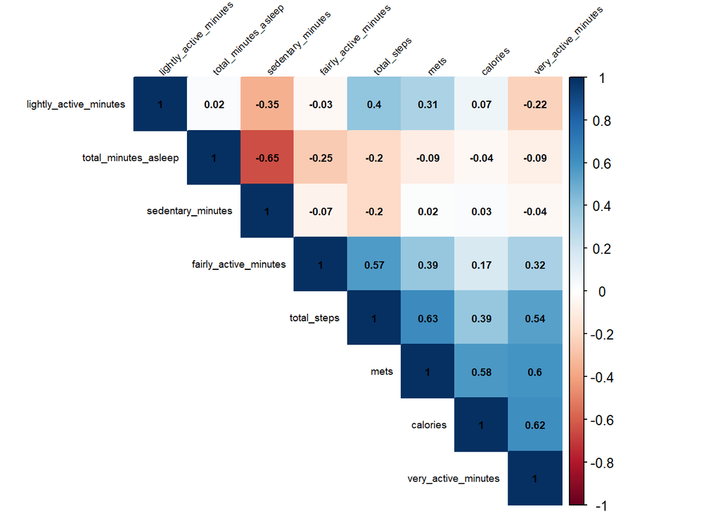

```r
# Calculate the correlation matrix
correlation_matrix <- cor(combined_data)
# Create a correlation plot
corrplot(correlation_matrix, method = "color", type = "upper",
         order = "hclust", tl.cex = 0.6, tl.col = "black",
         tl.srt = 45, addCoef.col = "black", number.cex = 0.6)
```

The correlation matrix shows a strong positive correlation between calories burned and very active minutes (0.62) and a notable negative correlation between sedentary minutes and total minutes asleep (-0.65), indicating that more intense physical activity may increase calorie burn, while increased sedentary time may be associated with less sleep.

Reminder: Correlation does not mean causation.

##### The relationship between Total Steps vs. METs with a regression line

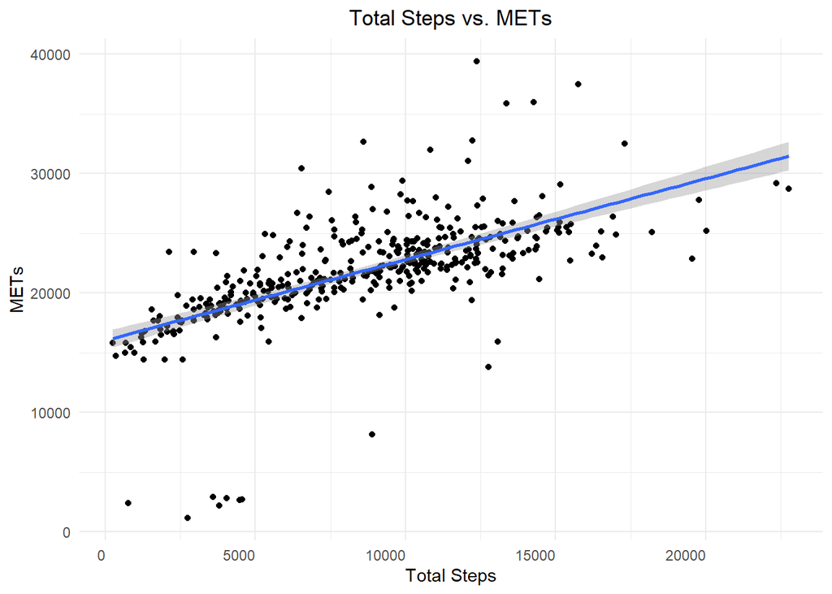

```r
# Scatter Plot for Total Steps vs. METs with a Regression Line
ggplot(data=combined_data, aes(x=total_steps, y=mets)) +
  geom_point() +
  geom_smooth(method="lm") +
  labs(title="Total Steps vs. METs", x="Total Steps", y="METs") +
  theme_minimal() +
  theme(axis.text.x = element_text(angle=0, hjust=1),
        plot.title = element_text(hjust = 0.5))
```

##### The relationship between Total Steps vs. Calories with a regression line

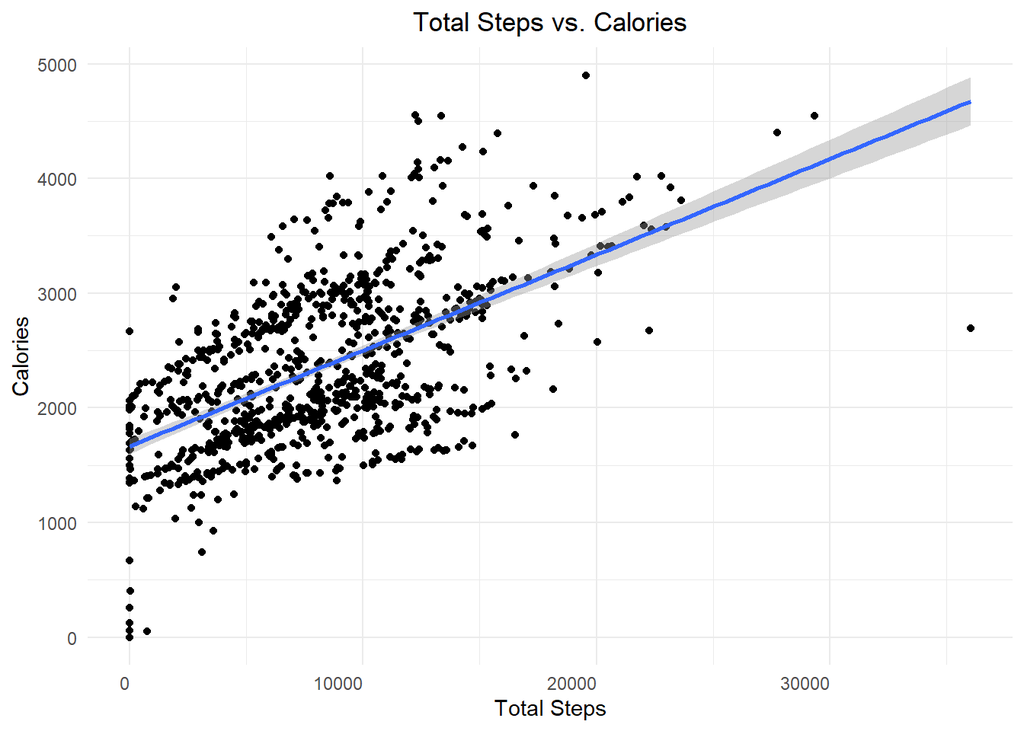

```r
# Scatter Plot for Total Steps vs. Calories with a Regression Line
ggplot(data=daily_activity, aes(x=total_steps, y=calories)) +
  geom_point() +
  geom_smooth(method="lm") +
  labs(title="Total Steps vs. Calories", x="Total Steps", y="Calories") +
  theme_minimal() +
  theme(axis.text.x = element_text(angle=0, hjust=1),
        plot.title = element_text(hjust = 0.5))
```

##### The relationship between Sedentary minutes vs. Total minutes asleep with a regression line

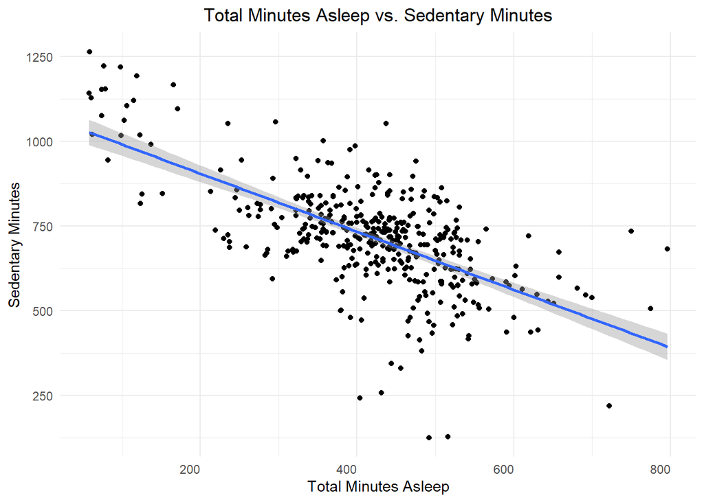

```r
# Scatter Plot for Total Steps vs. METs with a Regression Line
ggplot(data=combined_data, aes(x=total_minutes_asleep, y=sedentary_minutes)) +
  geom_point() +
  geom_smooth(method="lm") +
  labs(title="Total Minutes Asleep vs. Sedentary Minutes", x="Total Minutes Asleep", y="Sedentary Minutes") +
  theme_minimal() +
  theme(axis.text.x = element_text(angle=0, hjust=1),
        plot.title = element_text(hjust = 0.5))
```

##### Violin plot of total steps by day of the week

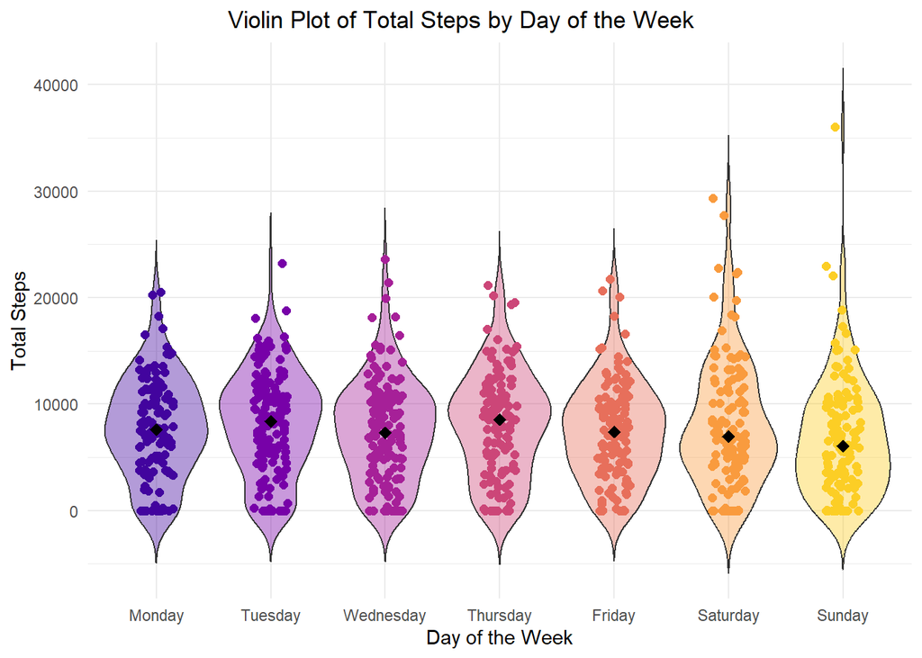

```r
# Extract day of the week from the date
daily_activity$day_of_week <- weekdays(daily_activity$date)

# Create a factor with the levels ordered correctly for days of the week
daily_activity$day_of_week <- factor(daily_activity$day_of_week, levels = c("Monday", "Tuesday", "Wednesday", "Thursday", "Friday", "Saturday", "Sunday"))

# Exclude the last date from the dataset
filtered_daily_activity <- daily_activity %>%
  filter(date != max(date))

# Create a violin plot with data points and median points
ggplot(filtered_daily_activity, aes(x = day_of_week, y = total_steps)) +
  geom_violin(aes(fill = day_of_week), trim = FALSE, alpha = 0.4) +
  geom_jitter(aes(color = day_of_week), width = 0.15, size = 2) +
  stat_summary(fun=median, geom="point", size=3, color="black", shape=18) + # Add median points
  labs(title = "Violin Plot of Total Steps by Day of the Week",
       x = "Day of the Week",
       y = "Total Steps") +
  theme_minimal() +
  theme(
    plot.title = element_text(hjust = 0.5),
    plot.title.position = "plot",
    legend.position = "none"  # Hides the legend
  ) +
  scale_fill_viridis_d(option = "C", end = 0.9, begin = 0.1, name = NULL) +
  scale_color_viridis_d(option = "C", end = 0.9, begin = 0.1, name = NULL)
```

##### Summary statistics of total steps by day of the week

```r
# Create a summary table
summary_table <- daily_activity %>%
  group_by(day_of_week) %>%
  summarize(
    Mean = round(mean(total_steps), 2),
    Median = round(median(total_steps), 2),
    Min = round(min(total_steps), 2),
    Max = round(max(total_steps), 2),
    SD = round(sd(total_steps), 2)
  ) %>%
  arrange(match(day_of_week, c("Monday", "Tuesday", "Wednesday", "Thursday", "Friday", "Saturday", "Sunday")))

# Display the table using knitr
knitr::kable(summary_table, caption = "Summary Statistics of Total Steps by Day of the Week")
```

Summary Statistics of Total Steps by Day of the Week

| day_of_week | Mean | Median | Min | Max | SD |
| --- | --- | --- | --- | --- | --- |
| Monday | 7780.87 | 7625.5 | 0 | 20500 | 4717.82 |
| Tuesday | 8125.01 | 8411.0 | 0 | 23186 | 4833.81 |
| Wednesday | 7559.37 | 7317.0 | 0 | 23629 | 4810.10 |
| Thursday | 7405.84 | 7860.0 | 0 | 21129 | 5007.99 |
| Friday | 7448.23 | 7408.0 | 0 | 21727 | 4648.04 |
| Saturday | 8152.98 | 6946.0 | 0 | 29326 | 5944.30 |
| Sunday | 6933.23 | 6083.0 | 0 | 36019 | 5644.24 |

The summary statistics of total steps taken across different days of the week reveal a nuanced pattern of physical activity. Notably, Tuesdays and Thursdays stand out with higher median steps, suggesting more consistent activity levels on these days. In contrast, while weekends, particularly Sundays, register the lowest median steps, they exhibit the highest maximum steps, indicating sporadic bursts of high activity, possibly linked to leisure or recreational activities.

This data suggests that while weekdays, especially Tuesdays and Thursdays, are characterized by steady, moderate activity levels, weekends are marked by greater variability in physical activity. The high standard deviations on weekends, especially Saturday, further underscore this inconsistency. These insights highlight an opportunity for targeted health and wellness interventions. Encouraging consistent activity throughout the week, particularly on weekends, could be beneficial. Additionally, given that daily step counts do not consistently reach the recommended 10,000 steps, integrating motivational features or personalized health recommendations into the app could nudge users towards more active lifestyles. Understanding these patterns and incorporating demographic data for a deeper customer segmentation analysis could lead to more effective, personalized user engagement strategies.

### Analysing Heart Rate Dataset

##### Summary statistics for heart rate values

```r
# Calculate summary statistics for heart rate values for each ID
summary_table_hr_by_id <- heartrate_seconds %>%
  group_by(id) %>%
  summarise(
  Mean = round(mean(value), 2),
  Median = round(median(value), 2),
  Min = round(min(value), 2),
  Max = round(max(value), 2),
  SD = round(sd(value), 2)
  ) %>%
  ungroup()  # Remove grouping

# Display the summary table
knitr::kable(summary_table_hr_by_id, caption = "Summary Statistics of Heart Rate by ID")
```

Summary Statistics of Heart Rate by ID

| id | Mean | Median | Min | Max | SD |
| --- | --- | --- | --- | --- | --- |
| 2022484408 | 80.24 | 76 | 38 | 203 | 17.60 |
| 2026352035 | 93.78 | 95 | 63 | 125 | 12.61 |
| 2347167796 | 76.72 | 73 | 49 | 195 | 15.52 |
| 4020332650 | 82.30 | 83 | 46 | 191 | 15.91 |
| 4388161847 | 66.13 | 62 | 39 | 180 | 15.85 |
| 4558609924 | 81.67 | 80 | 44 | 199 | 14.13 |
| 5553957443 | 68.63 | 64 | 47 | 165 | 14.82 |
| 5577150313 | 69.56 | 62 | 36 | 174 | 20.96 |
| 6117666160 | 83.75 | 84 | 52 | 189 | 14.12 |
| 6775888955 | 92.03 | 91 | 55 | 177 | 17.60 |
| 6962181067 | 77.72 | 73 | 47 | 184 | 17.00 |
| 7007744171 | 91.12 | 90 | 54 | 166 | 13.99 |
| 8792009665 | 72.49 | 70 | 43 | 158 | 13.71 |
| 8877689391 | 83.61 | 72 | 46 | 180 | 30.60 |

##### Boxplot for each ID

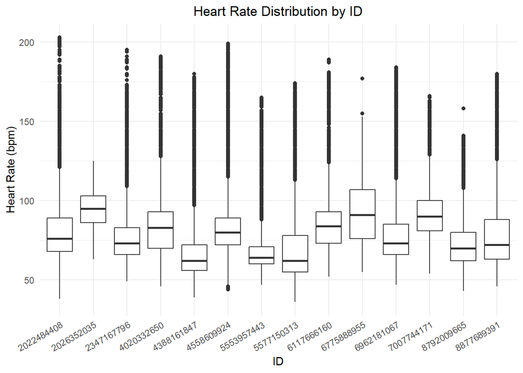

```r
# Boxplot for each ID
ggplot(heartrate_seconds, aes(x = factor(id), y = value)) +
  geom_boxplot() +
  labs(title = "Heart Rate Distribution by ID",
       x = "ID",
       y = "Heart Rate (bpm)") +
  theme_minimal() +
  theme(axis.text.x = element_text(angle = 30, hjust = 1),
        plot.title = element_text(hjust = 0.5))   # Rotate x-axis labels for better readability
```

The summary statistics of heart rate by ID illustrate diverse physiological patterns among individuals. Mean heart rates range from approximately 66 to 93 bpm, indicating varied resting or active states. The closely aligned means and medians suggest symmetrical distributions for most individuals. The extensive range in minimum and maximum heart rates, from as low as 36 bpm to as high as 203 bpm, reflects the breadth of physical states, from rest to high activity. The standard deviations, varying significantly across IDs, highlight the distinct fluctuations in heart rate each person experiences.

Overall,The summary table and the boxplot suggest that each individual’s heart rate pattern is unique, potentially influenced by a variety of factors including physical activity, overall health, and lifestyle habits. Such insights can be invaluable for personalized health monitoring and targeted interventions.

### Analysing Intensities Data

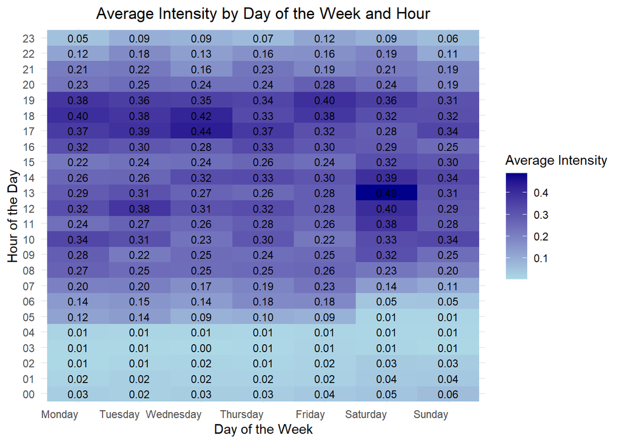

```r
# Convert the activity_hour column to datetime
hourly_intensities$activity_hour <- as.POSIXct(hourly_intensities$activity_hour, format="%m/%d/%Y %I:%M:%S %p")

# Extract the day of the week and hour
hourly_intensities$day_of_week <- weekdays(hourly_intensities$activity_hour)
hourly_intensities$hour <- format(hourly_intensities$activity_hour, "%H")

# Aggregate to get average intensity per hour for each day of the week
average_intensity_by_hour <- hourly_intensities %>%
  group_by(day_of_week, hour) %>%
  summarise(average_intensity = mean(average_intensity, na.rm = TRUE)) %>%
  ungroup()

# Reorder the days of the week
average_intensity_by_hour$day_of_week <- factor(average_intensity_by_hour$day_of_week,
                                                levels = c( "Monday", "Tuesday", "Wednesday", "Thursday", "Friday", "Saturday","Sunday"))

# Create the plot with a single color gradient and numbers on boxes
ggplot(average_intensity_by_hour, aes(x=day_of_week, y=hour, fill=average_intensity)) +
  geom_tile() +
  geom_text(aes(label = sprintf("%.2f", average_intensity)), color = "black", size = 3) +  # Add numbers on boxes, rounded to two decimals
  scale_fill_gradient(low = "lightblue", high = "darkblue", name = "Average Intensity") +
  scale_x_discrete(limits = c( "Monday", "Tuesday", "Wednesday", "Thursday", "Friday", "Saturday", "Sunday")) +  # Adjust x-axis for discrete values
  scale_y_discrete(breaks = unique(average_intensity_by_hour$hour)) +  # Adjust y-axis dimensions
  labs(title="Average Intensity by Day of the Week and Hour",
       x="Day of the Week",
       y="Hour of the Day") +
  theme_minimal() +
  theme(axis.text.x = element_text(angle=0, hjust=1),
        plot.title = element_text(hjust = 0.5))
```

The analysis of hourly intensities across different days of the week reveals distinct peaks in user activity, particularly in the evening, especially between 5 PM and 7 PM on Wednesdays, indicating a midweek surge in physical activities, possibly due to post-work exercise routines. Additionally, activity levels on Saturday around noon time are notably higher than other days, suggesting that users might be engaging in outdoor activities or workouts during weekend leisure time. This information is beneficial for Bellabeat, as it can tailor its engagement strategies by sending targeted reminders or motivational content during these peak hours. Encouraging users to maintain or increase physical activities during these times can optimize app engagement and promote a healthier lifestyle, especially for those with a tendency towards sedentary behavior on weekdays.

### Analysing Daily Sleep Dataset

##### Box plot for total minus asleep per capita

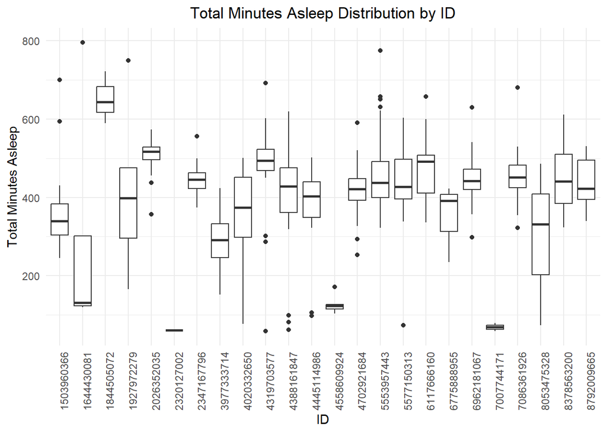

```r
# Boxplot for total minutes asleep
ggplot(sleep_day, aes(x = factor(id), y = total_minutes_asleep)) +
  geom_boxplot() +
  labs(title = "Total Minutes Asleep Distribution by ID",
       x = "ID",
       y = "Total Minutes Asleep") +
  theme_minimal() +
 theme(axis.text.x = element_text(angle = 90, hjust = 1),
        plot.title = element_text(hjust = 0.5))
```

##### Violin plot of total hours asleep by day of the week

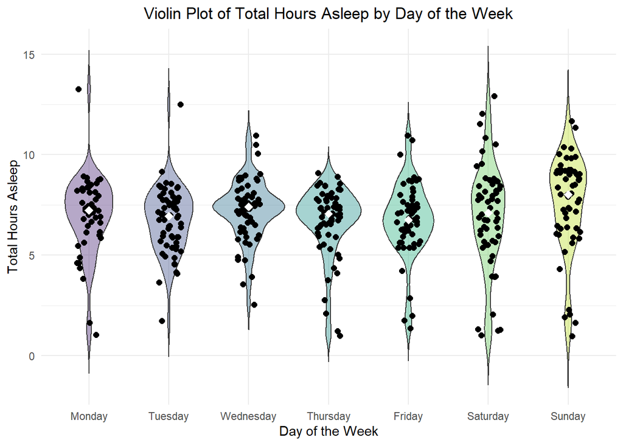

```r
# Extract day of the week from the date
sleep_day$day_of_week <- weekdays(sleep_day$date)

# Create a factor with the levels ordered correctly for days of the week
sleep_day$day_of_week <- factor(sleep_day$day_of_week, levels = c("Monday", "Tuesday", "Wednesday", "Thursday", "Friday", "Saturday", "Sunday"))

# Create a violin plot for total hours asleep by day of the week
ggplot(sleep_day, aes(x = day_of_week, y = total_minutes_asleep/60, fill = day_of_week)) +
  geom_violin(trim = FALSE, alpha = 0.4) +
  geom_jitter(width = 0.15, size = 2) +
  stat_summary(fun = median, geom = "point", size = 3, color = "white", shape = 18) + # Add median points
  labs(title = "Violin Plot of Total Hours Asleep by Day of the Week",
       x = "Day of the Week",
       y = "Total Hours Asleep") +
  theme_minimal() +
  theme(
    plot.title = element_text(hjust = 0.5),
    legend.position = "none"
  ) +
  scale_fill_viridis_d(begin = 0.1, end = 0.9)
```

```r
# Note: Adjust the plot aesthetics as necessary
```

##### Summary statistics of total hours asleep by day of the week

```r
# Add a column for day of the week
sleep_day$day_of_week <- weekdays(as.Date(sleep_day$date))

# Create a factor with the levels ordered correctly for days of the week
sleep_day$day_of_week <- factor(sleep_day$day_of_week, levels = c("Monday", "Tuesday", "Wednesday", "Thursday", "Friday", "Saturday", "Sunday"))

# Create a summary table for total hours asleep by day of the week, rounded to 2 decimal places
summary_table_sleep <- sleep_day %>%
  group_by(day_of_week) %>%
  summarize(
    Mean = round(mean(total_minutes_asleep / 60), 2),
    Median = round(median(total_minutes_asleep / 60), 2),
    Min = round(min(total_minutes_asleep / 60), 2),
    Max = round(max(total_minutes_asleep / 60), 2),
    SD = round(sd(total_minutes_asleep / 60), 2)
  ) %>%
  arrange(match(day_of_week, c("Monday", "Tuesday", "Wednesday", "Thursday", "Friday", "Saturday", "Sunday")))

# Display the summary table
knitr::kable(summary_table_sleep, caption = "Summary Statistics of Total Hours Asleep by Day of the Week")
```

Summary Statistics of Total Hours Asleep by Day of the Week

| day_of_week | Mean | Median | Min | Max | SD |
| --- | --- | --- | --- | --- | --- |
| Monday | 6.99 | 7.23 | 1.03 | 13.27 | 2.00 |
| Tuesday | 6.74 | 6.95 | 1.72 | 12.50 | 1.60 |
| Wednesday | 7.24 | 7.41 | 2.53 | 10.97 | 1.50 |
| Thursday | 6.69 | 7.06 | 0.98 | 9.08 | 1.71 |
| Friday | 6.76 | 6.75 | 1.37 | 10.97 | 1.88 |
| Saturday | 6.98 | 7.10 | 1.02 | 12.92 | 2.59 |
| Sunday | 7.55 | 8.02 | 0.97 | 11.67 | 2.42 |

#### Relationship between Minutes Asleep and Sedentary Minutes

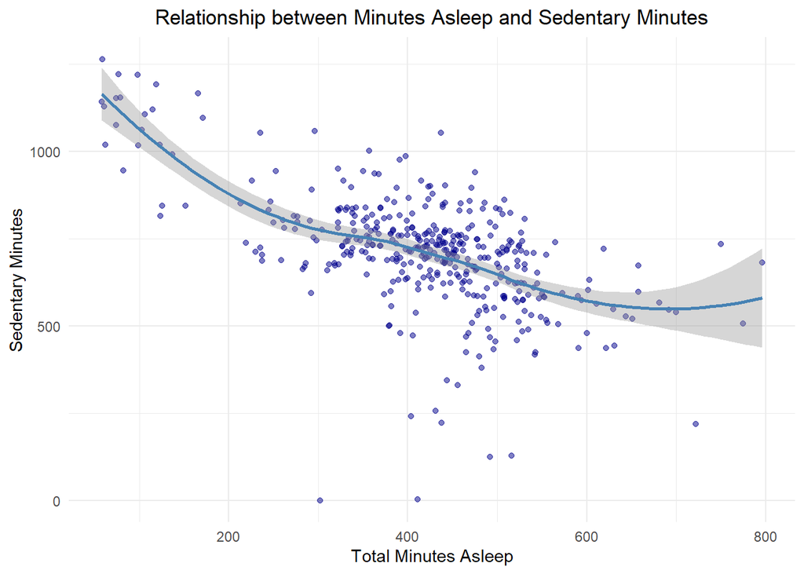

```r
# Merge the sleep_day and daily_activity datasets by 'id' and 'date'
merged_data <- merge(sleep_day, daily_activity, by=c('id', 'date'))

# Get a quick overview of the merged dataset to ensure it merged correctly
# glimpse(merged_data)

# Create a scatter plot of total minutes asleep vs. sedentary minutes
ggplot(data=merged_data, aes(x=total_minutes_asleep, y=sedentary_minutes)) +
  geom_point(color='darkblue', alpha=0.5) +  # Points are colored dark blue with 50% transparency to reduce overplotting
  geom_smooth(method="loess", color="steelblue") +  # Add a loess smoothed trend line in steel blue to highlight the overall trend
  labs(title="Relationship between Minutes Asleep and Sedentary Minutes",
       x="Total Minutes Asleep",
       y="Sedentary Minutes") +  # Add labels and title for clarity
  theme_minimal() +  # Use a minimal theme for a clean look
  theme(legend.position="bottom",
        plot.title = element_text(hjust = 0.5))  # Position the legend at the bottom
```

```r
# Note that geom_smooth() by default includes a 95% confidence interval around the smooth line
# This shaded area gives an idea of the uncertainty around the trend estimate
```

From the plot, I can observe that individuals with fewer minutes asleep tend to have higher sedentary minutes, which could indicate less restful sleep or shorter sleep duration correlating with longer periods of inactivity during waking hours. On the other hand, those with more minutes asleep tend to have fewer sedentary minutes, suggesting that better-rested individuals might be more active.

## Act

### Strategic Recommendations

Based on the analysis of the Fitbit Fitness Tracker Data, several actionable strategies for Bellabeat can be proposed:

1. **Personalized Sleep Insights**: Develop features offering personalized sleep analysis and recommendations, focusing on days with observed reduced sleep.
2. **Sedentary Behavior Alerts**: Implement alerts to encourage movement after periods of inactivity, especially during high sedentary times.
3. **Optimize Engagement for Peak Activity Hours**: Create engagement strategies and motivational content targeting peak activity periods, like weekday evenings and Saturday noons.
4. **Targeted Wellness Interventions**: Develop interventions for consistent physical activity throughout the week, leveraging insights from daily activity patterns.
5. **Enhanced Data Collection**: Expand data collection to include demographic information for more segmented and targeted analysis, tailoring products and marketing to specific consumer groups and preferences.
6. **Sleep-Activity Balance Insights**: Integrate features in Bellabeat’s app to analyse the link between sleep duration and sedentary behaviour, guiding users towards improving sleep quality and increasing physical activity for a healthier lifestyle balance.

### Possible Implementation Plan

1. **Product Development**: Integrate insights into product development, focusing on features that align with the identified activity and sleep patterns.
2. **Marketing Campaigns**: Craft marketing campaigns emphasizing the benefits of consistent physical activity and good sleep, highlighting how Bellabeat products aid in achieving these goals.
3. **Customer Engagement**: Utilize data for customer engagement strategies, offering personalized notifications and rewards for meeting activity and sleep objectives.
4. **Continuous Monitoring**: Set up a continuous data analysis framework to assess the effectiveness of strategies and make necessary adjustments.

## Conclusion

The analysis of the Fitbit Fitness Tracker Data has yielded several actionable insights that can inform Bellabeat’s strategic decisions regarding product development and marketing. I’ve identified key patterns in physical activity, sleep, sedentary behavior and peak activity hours that can guide the creation of personalized user experiences and health-driven community engagement.

However, it is important to acknowledge the limitations of this analysis. The dataset used is relatively small and dated, as it represents a sample from 2016 and may not reflect current trends or the wider demographic Bellabeat targets. The observed discrepancies in sleep data raise concerns about data quality, indicating potential inconsistencies in measurement methods or recording accuracy. The absence of demographic information within the dataset limits the depth of our customer segmentation and the personalisation of insights. Additionally, the data is sourced from a third-party and may not fully represent the user engagement that Bellabeat’s own products would elicit.

Despite these limitations, the strategic recommendations provided offer a foundation for Bellabeat to enhance its user engagement and product features. It is crucial for Bellabeat to continue investing in data collection and analysis, particularly gathering more current and comprehensive data that includes demographic details. This will enable Bellabeat to refine its strategies, ensuring they are based on accurate and representative insights. By continually adapting to the evolving needs and preferences of its users, Bellabeat can maintain a competitive edge in the health and wellness technology market.